# Basic Visualizations

Connor Flynn | Victoria DelaCruz

### Today’s Topics

Welcome to Basic Visualizations! We’re going to go over some code on how to create our first visualizations using our SDR 2023 Data.

1. Scatter plot
2. Bar chart
3. Histogram
4. Challenge!

### Setup

#### Loading Libraries

Let’s load in the `tidyverse`, `janitor`, and `here` libraries as we’ll be using different functions within these packages.

- It is best practice to load all of your libraries within the first code chunk of your R Markdown

```r
knitr::opts_chunk$set(echo = TRUE)
library(tidyverse)
library(here)
library(janitor)
```

#### Reading in Data

Next, let’s read in our data and assign it to the variable `sdr_data`.

- We use the same functions as we did in the previous lesson
  - `read_csv()` and `here()`

```r
sdr_data <- read_csv(here("data/SDR-2023-Data.csv"))
```

Use the `clean_names` function from the janitor package to clean up the column names of our dataframe.

```r
sdr_data <- sdr_data %>%
  clean_names()
```

#### `ggplot()`

We’re going to be using the `ggplot()` frequently to graph our visualizations. ggplot is a powerful visualization package for R and allows for customization in creating our plots. Here are some basic concepts and inputs in ggplot:

1. Specify the dataframe you would like to plot from
2. Aesthetics: decide what your x and y variables are, color schemes, size, etc.
- aesthetics will always be columns in your dataframe
3. Geometric objects/geoms: decide if you’re graphing with points, lines, bars, etc.
4. Statistical transformations/stats: think about if you want to include a smooth line, visualize regressions, etc.
5. Facets: consider using facets to create separate plots if you have multiple categories

### Scatterplot

When should we use a **scatterplot**?

Scatterplots are helpful in visualizing relationships between two continuous variables. For instance, we can identify patterns or trends between two variables, clusters or groups, or compare. Let’s review the [from Data to Viz](https://www.data-to-viz.com/) resource to learn more.

Let’s make our first plot!

In the following code, we’re:

- Using the `ggplot()` function
- Passing our dataframe `sdr_data` to the data argument
- Putting SDG 3 Scores on the x axis
- Putting SDG 4 Scores on the y axis
- Using `geom_point()` to make a scatter plot where each point is a country and it’s location on the graph is based on the country’s SDG 3 scores and SDG 4 scores

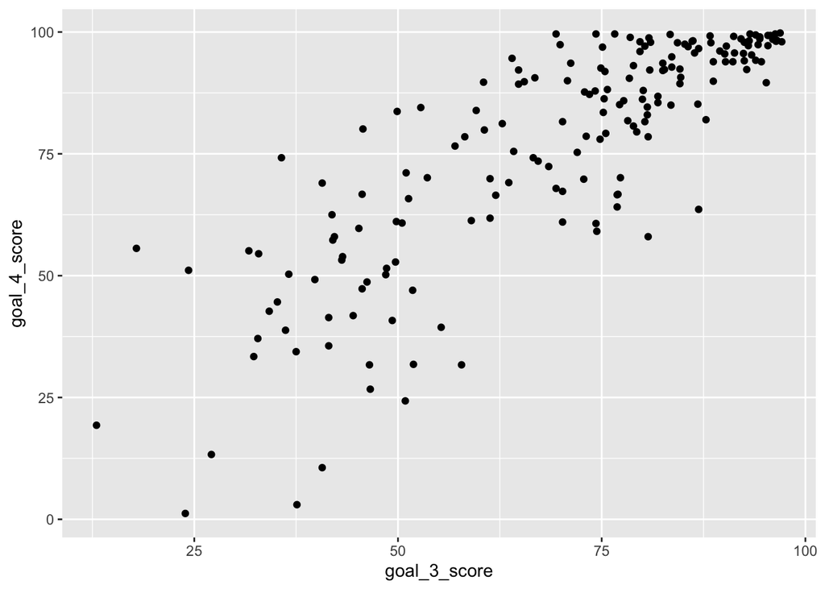

```r
ggplot(data = sdr_data, aes(x= goal_3_score, y = goal_4_score)) +
  geom_point()
```

Awesome! What if we wanted to color the points/countries based on their region? Let’s use the `color` argument to add some color to do so.

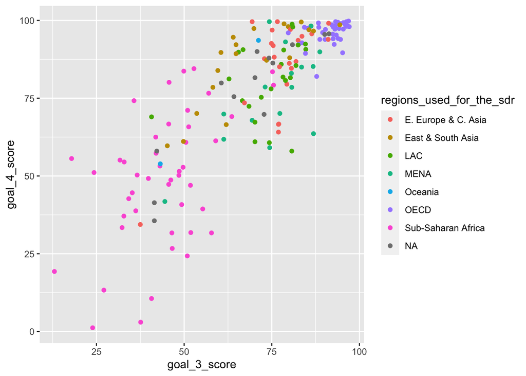

```r
ggplot(data = sdr_data, aes(x= goal_3_score, y = goal_4_score, color = regions_used_for_the_sdr)) +
  geom_point()
```

Interpretation: Many countries in Sub-Saharan Africa seem to be in the lower left quadrant of our graph, meaning they aren’t doing as well in good health and well-being (SDG 3) and quality education (SDG 4) compared to the rest of the world. There seems to be a cluster or group of countries that belong to the OECD region on the top right quadrant, meaning they’re doing better in terms of these goals.

- You may be thinking, what is OECD?
  - The regions_used_for_the_sdr column groups countries by geographic region, except for countries part of the OECD, which stands for the Organization for Economic Co-operation and Development (OECD).
  - Two major differences between OECD countries and non-OECD countries are the amount of primary energy that they consume and their population growth. The countries that participate in OECD tend to be wealthier countries and use quite a bit more primary energy per capita.

Let’s create one more scatter plot!

- So far we have only colored by the *categorical* variable region.
  - We can also color by *continuous* variables like the other SDG Scores.
    - Let’s pass goal_5_score to the color argument to color each point/country based on their SDG 5 score.

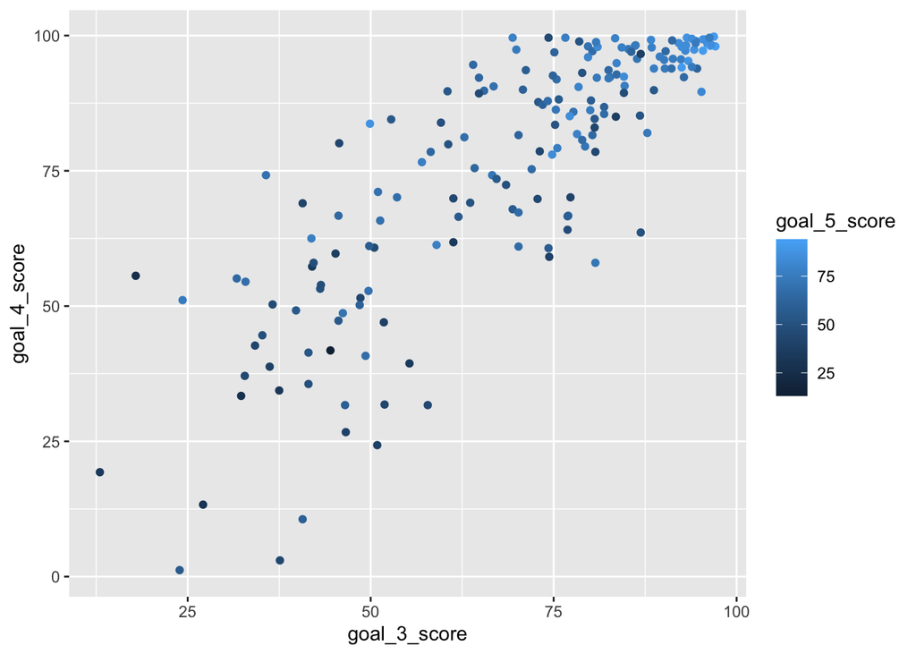

```r
ggplot(data = sdr_data, aes(x= goal_3_score, y = goal_4_score, color = goal_5_score)) +
  geom_point()
```

Cool! It seems that the darkest blue points (countries with the lowest SDG 5 scores) tend to have mid-range or low SDG 3 / SDG 4 scores as well. The lightest blue points (countries with the highest SDG 5 scores) tend to have high SDG 3 / SDG 4 scores as well. However, there are several countries that do not follow this trend.

#### Challenge 1

Create a scatterplot using two different SDG scores. Then, color the points by using a third SDG score. In a couple of sentences, describe what you see.

### Bar Chart

When should we use a **bar chart**?

A bar chart is great for comparing a numeric variable by group.

- In this case, let’s try to compare our numeric variable (SDG 3 Scores) by group (country)

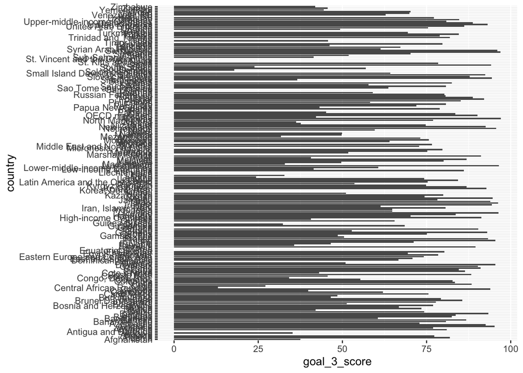

```r
ggplot(sdr_data, aes(x= goal_3_score, y = country)) +
  geom_bar(stat = "identity")
```

Hmm… it looks like the country names are hard to read - there are too many of them! Let’s try to look at a specific region.

- To do this, let’s use the `filter()` function we learned about in our last lesson
  - We’ll create a new dataframe from our original dataframe, sdr_data, called lac_sdr_data that only includes countries in Latin America and the Carribean

```r
lac_sdr_data <- sdr_data %>%
  filter(regions_used_for_the_sdr == "LAC") # filtering for LAC countries only
```

Now let’s make a bar chart from our new dataframe `lac_sdr_data`

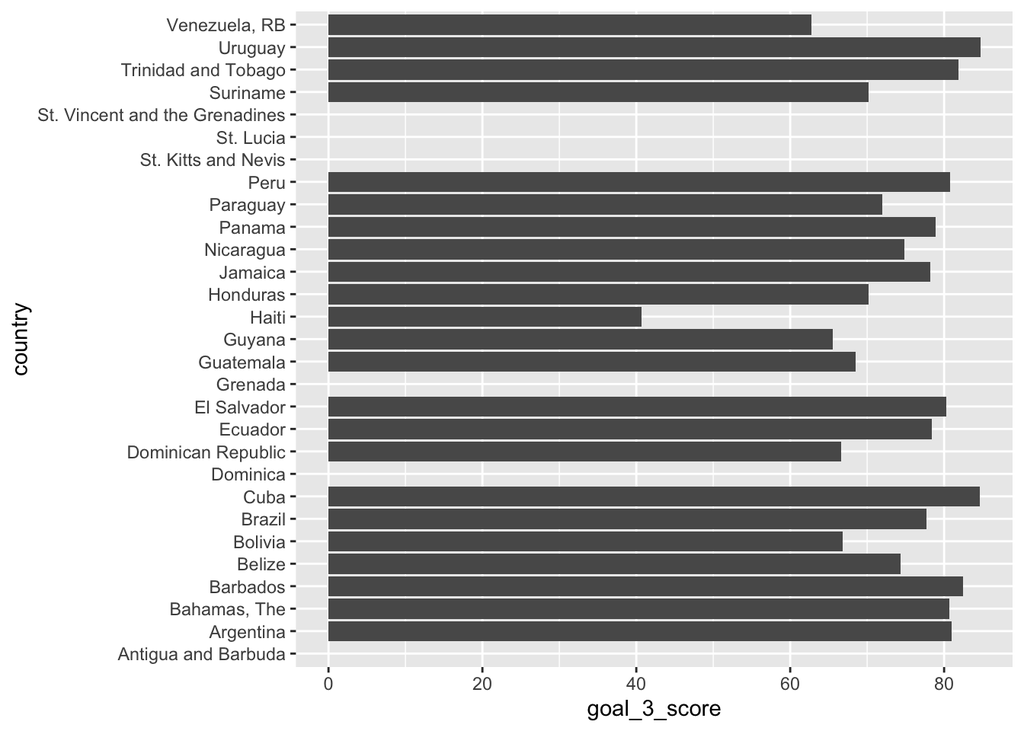

```r
ggplot(lac_sdr_data, aes(x= goal_3_score, y = country)) +
  geom_bar(stat = "identity")
```

#### Faceted Bar Chart

As we talked about in ggplot, let’s try to use faceting. Considering that regions_used_for_the_sdr is a *categorical* variable, we can create separate plots based on regions.

- To do this, we add a `+` to our code and use the `facet_wrap()` function
  - We seperate the plots by region so we put our region column `regions_used_for_the_sdr` into the `facet_wrap()` function
    - Then we set scales = “free_y”
      - This so each subplot only contains the countries in that region instead of all countries
  - We also adjust the y axis text size to make everything fit nicely

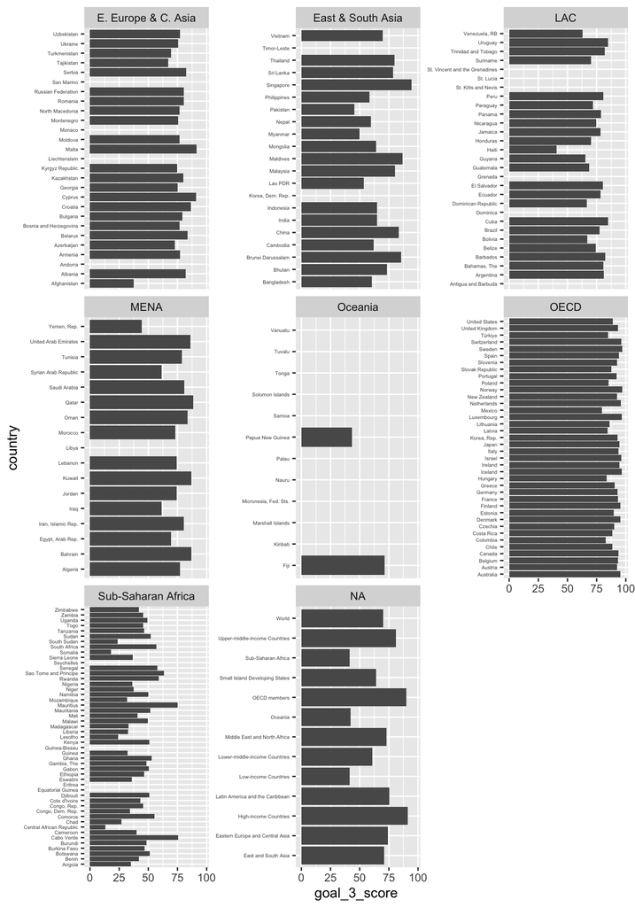

```r
ggplot(sdr_data, aes(x= goal_3_score, y = country)) +
  geom_bar(stat = "identity") +
  facet_wrap(~regions_used_for_the_sdr, scales = "free_y") + # faceting for regions
  theme(axis.text.y = element_text(size = 4)) # adjusting text size of y-axis values
```

Interpretation: As we can see in the Oceania region, most Countries do not have the necessary data to calculate a SDG 3 Score. Sub-Saharan Africa appears to have some of the lowest Goal 3 Scores, while OECD has some of the highest.

#### Challenge 2

Create a new bar chart with countries only from the MENA region.

### Histogram

When do we use a **histogram**?

Histograms are awesome at visualizing distributions of a single continuous variable.

- Let’s check out the distribution for SDG 4 Scores globally

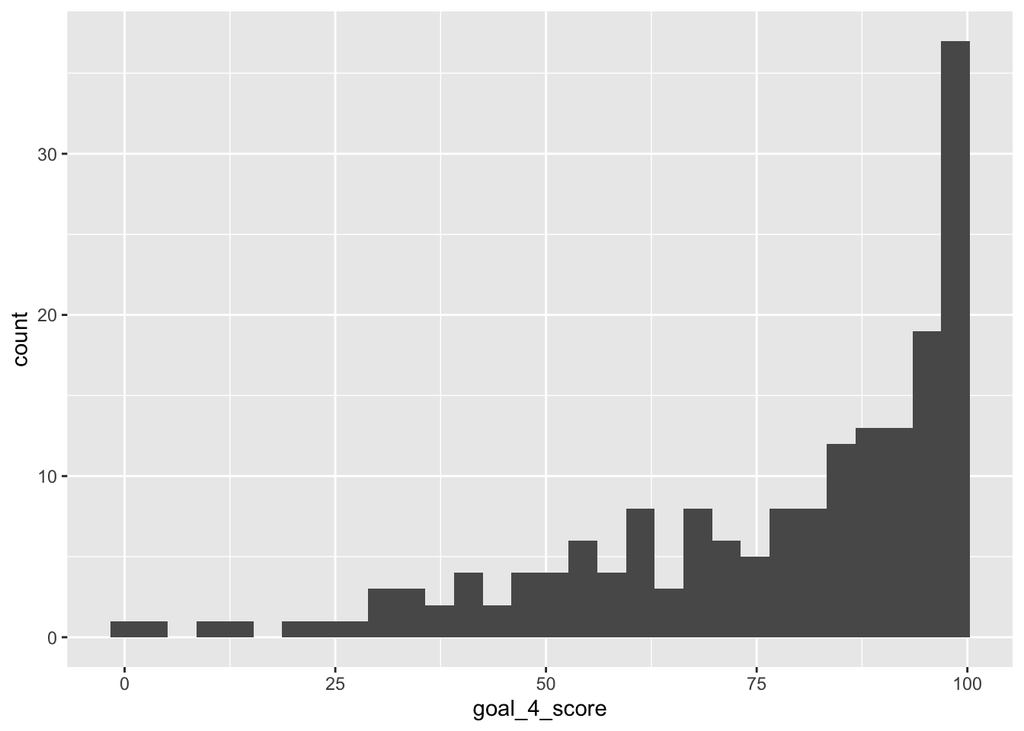

```r
ggplot(sdr_data, aes(x = goal_4_score)) +
  geom_histogram()
```

Each bar/bin represents a range of SDG 4 Scores. There are 30 bars/bins so each bar/bin has a range of about 3.3.

- The height of the bar/bin represent the number of countries that fall into that SDG 4 Score Range.
  - About 37 countries fall into the 97-100 SDG 4 Score Range. This is the most popular range.
  - About 19 countries fall into the 94-97 SDG 4 Score Range, and so on

This is great for looking at the distribution of Goal 4 scores, but let’s explore further with adding another layer of visualization.

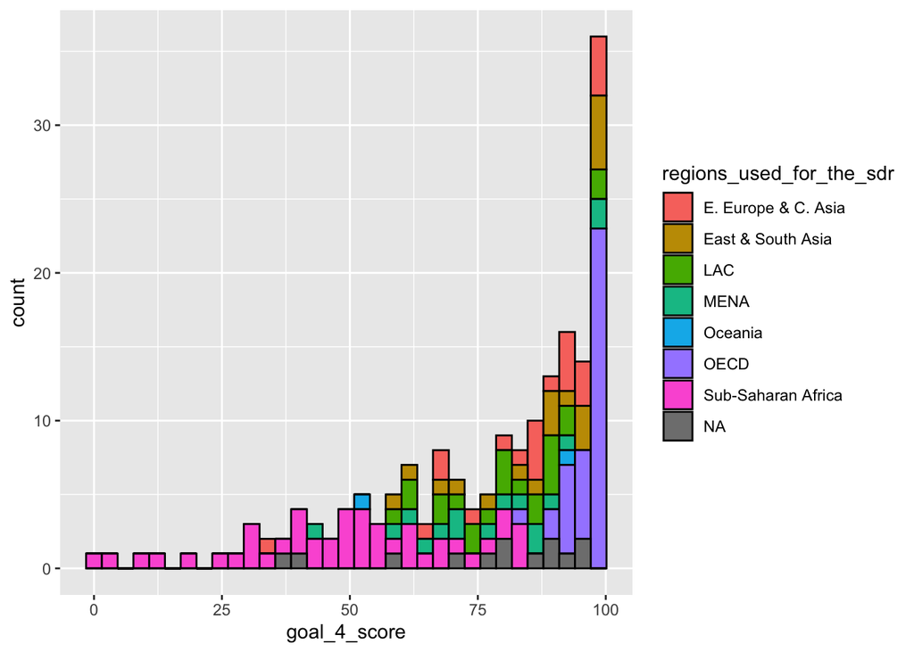

```r
ggplot(sdr_data, aes(x = goal_4_score, fill=regions_used_for_the_sdr)) +
  geom_histogram(bins=33, color="black")
```

Interpretation: Countries that fall in the higher end of the Goal 4 spectrum belong to the OECD region, while countries in Sub-Saharan Africa lie towards the lower end.

#### Challenge 3

Make a histogram for a different SDG score. Then, fill by region. In a couple of sentences, describe any interesting trends or what you notice from your new histogram.